# Analysis of Munc on Bassoon Data

```r
    knitr::opts_knit$set(root.dir = normalizePath("../../Desktop/Kittel_Lab/macro_output/"))
```

```r
getwd()
```

```
[1] "/Users/tbullmann/Desktop/Kittel_Lab/macro_output"
```

# Data

## Load data

```r
filenames <- Sys.glob("*.bassoon.csv")  # get a list of bassoon results
BassoonBlobs <- lapply(filenames, function(.file){
  dat<-read.csv(.file, header=T)
  dat$filename<-as.character(.file)
  dat    # return the dataframe
})
BassoonBlobs <- do.call(rbind, BassoonBlobs) # combine into a single dataframe
```

Parsing filenames

```r
# E followed by a integer number of any length, followed by a _ and then anything
BassoonBlobs$experiment <- sub("E(\\d*)_.*", "\\1", BassoonBlobs$filename)
# anything followed by _ then a string without _, followed by _ and then again anything
BassoonBlobs$treatment <- sub(".*_([^_]+)_.*", "\\1", BassoonBlobs$filename)
# last number before the dot = anything followed by a number of any length, followed by a . and anything
BassoonBlobs$dish <- sub(".*_(\\d*)\\..*", "\\1", BassoonBlobs$filename)
```

Munc counts are integers

```r
BassoonBlobs$Munc_count <- as.integer(BassoonBlobs$Munc_count)
```

Removing Munc count of background

```r
BassoonBlobs<-BassoonBlobs[!(BassoonBlobs$Bassoon_id==0),]
```

```r
BassoonBlobs$Marker <- ifelse(BassoonBlobs$experiment %in% c(6,7,9), "VGAT", "VGluT1")
```

# Descriptive statistics

```r
library(lattice)
```

## Effect of TTX

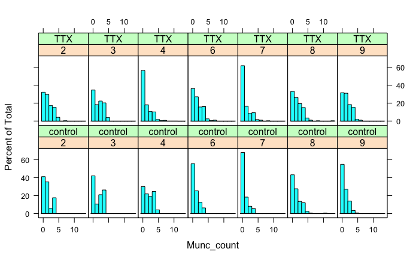

```r
histogram(~Munc_count|experiment+treatment,auto.key=TRUE,data=BassoonBlobs)
```

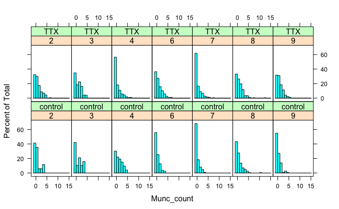

```r
histogram(~Munc_count|experiment+treatment,auto.key=TRUE,data=BassoonBlobs, breaks=-1:15)
```

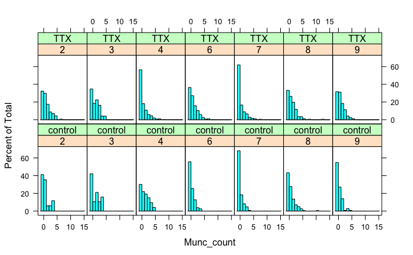

```r
histogram(~Munc_count|experiment+treatment,auto.key=TRUE,data=subset(BassoonBlobs,Marker_overlap=1), breaks=-1:15)
```

## Depending on synapse type

Instead of plotting for experiments, pooling all experiments with same Marker.

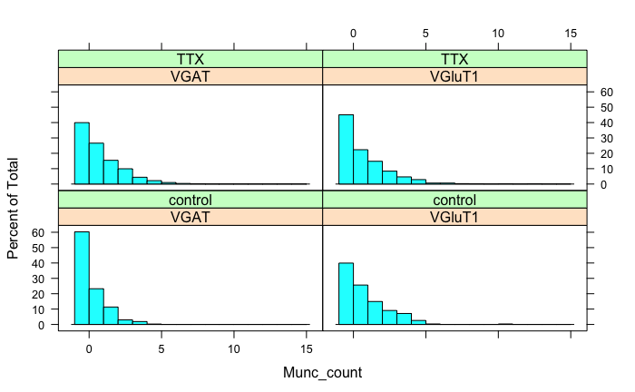

```r
histogram(~Munc_count|Marker+treatment,auto.key=TRUE, data=subset(BassoonBlobs, Marker_overlap=1), breaks=-1:15)
```

### Restricted to experiments with Sakamoto Munc antibody

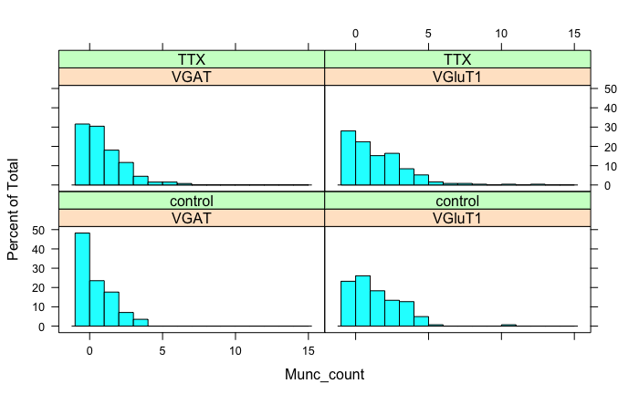

```r
histogram(~Munc_count|Marker+treatment,auto.key=TRUE,data=subset(BassoonBlobs, as.numeric(experiment)>2 & Marker_overlap==1 ), breaks=-1:15)
```

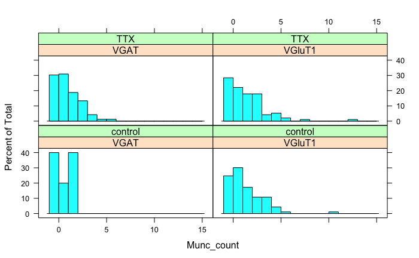

```r
histogram(~Munc_count|Marker+treatment,auto.key=TRUE,data=subset(BassoonBlobs, as.numeric(experiment)>7 & Marker_overlap==1 ), breaks=-1:15)
```

# Modelling of Munc per Bassoon

Clearly, the count of munc spots per basson blob does not follow a normal distribution and we cannot use standard Linear Regression models like ANOVA to fit the data. Generalized Linear Models are models in which response variables follow a distribution other than the normal distribution. Specifically, we will use a Poisson Regression models, which are best used for modeling events where the outcomes are counts.

## Effect of TTX

```r
model = glm(Munc_count ~ treatment + experiment, data=BassoonBlobs, family = poisson(link = "log"))
summary(model)
```

```
Call:
glm(formula = Munc_count ~ treatment + experiment, family = poisson(link = "log"),
    data = BassoonBlobs)

Deviance Residuals:
    Min       1Q   Median       3Q      Max
-1.7862  -1.5256  -0.2795   0.6008   5.7246

Coefficients:
             Estimate Std. Error z value Pr(>|z|)
(Intercept)   0.08440    0.07707   1.095  0.27345
treatmentTTX  0.28310    0.04774   5.930 3.03e-09 ***
experiment3   0.09949    0.11806   0.843  0.39938
experiment4  -0.21582    0.07642  -2.824  0.00474 **
experiment6  -0.10046    0.07949  -1.264  0.20633
experiment7  -0.60970    0.09254  -6.588 4.45e-11 ***
experiment8   0.05429    0.07949   0.683  0.49463
experiment9  -0.13149    0.07560  -1.739  0.08197 .
---
Signif. codes:  0 ‘***’ 0.001 ‘**’ 0.01 ‘*’ 0.05 ‘.’ 0.1 ‘ ’ 1

(Dispersion parameter for poisson family taken to be 1)

    Null deviance: 4145.8  on 2290  degrees of freedom
Residual deviance: 4013.1  on 2283  degrees of freedom
AIC: 7194

Number of Fisher Scoring iterations: 6
```

The Residual deviance is larger than degrees of freedom. This indicates **overdisperion**. In general, poisson distribution the variance is equal to the mean. We can test for the overdispersion by comparing the expected to the modeled residuals using this approxiate: https://bbolker.github.io/mixedmodels-misc/glmmFAQ.html#overdispersion.

```r
overdisp_fun <- function(model) {
rdf <- df.residual(model)
rp <- residuals(model,type="pearson")
Pearson.chisq <- sum(rp^2)
prat <- Pearson.chisq/rdf
pval <- pchisq(Pearson.chisq, df=rdf, lower.tail=FALSE)
c(chisq=Pearson.chisq,ratio=prat,rdf=rdf,p=pval)
}
```

```r
overdisp_fun(model)
```

```
        chisq         ratio           rdf             p
 4.202095e+03  1.840602e+00  2.283000e+03 7.449688e-117
```

Overdispersion means that the variance is much greater than the mean. Our model is to simple to explain this excess variance in the data. The general idea is to add another predictor to our model and which we do not really care for: a *random* effect. This could be the variation introduced by choosing a field of view for taking the image. This is in contrast to predictor we varied on purpose: a *fixed* effect. The modelling of these **mixed effect models** can be done by the package **lme4**.

```r
library(lme4)
model = glmer(Munc_count ~ treatment + experiment + (1|dish), data=BassoonBlobs, family = poisson(link = "log"))
summary(model)
```

```
Generalized linear mixed model fit by maximum likelihood (Laplace Approximation) ['glmerMod']
 Family: poisson  ( log )
Formula: Munc_count ~ treatment + experiment + (1 | dish)
   Data: BassoonBlobs

     AIC      BIC   logLik deviance df.resid
  7008.9   7060.5  -3495.4   6990.9     2282

Scaled residuals:
    Min      1Q  Median      3Q     Max
-1.5342 -0.9347 -0.3708  0.5716  9.6542

Random effects:
 Groups Name        Variance Std.Dev.
 dish   (Intercept) 0.1644   0.4055
Number of obs: 2291, groups:  dish, 11

Fixed effects:
             Estimate Std. Error z value Pr(>|z|)
(Intercept)  -0.12099    0.14820  -0.816   0.4143
treatmentTTX  0.41413    0.05063   8.180 2.84e-16 ***
experiment3   0.10875    0.13128   0.828   0.4074
experiment4   0.17952    0.08320   2.158   0.0310 *
experiment6  -0.16154    0.09548  -1.692   0.0907 .
experiment7  -0.58504    0.11261  -5.195 2.04e-07 ***
experiment8   0.04909    0.09376   0.524   0.6006
experiment9  -0.11428    0.09977  -1.145   0.2521
---
Signif. codes:  0 ‘***’ 0.001 ‘**’ 0.01 ‘*’ 0.05 ‘.’ 0.1 ‘ ’ 1

Correlation of Fixed Effects:
            (Intr) trtTTX exprm3 exprm4 exprm6 exprm7 exprm8
treatmntTTX -0.313
experiment3 -0.242  0.114
experiment4 -0.399  0.133  0.385
experiment6 -0.368 -0.023  0.308  0.513
experiment7 -0.363  0.057  0.284  0.455  0.663
experiment8 -0.434  0.156  0.336  0.556  0.719  0.688
experiment9 -0.383 -0.015  0.311  0.499  0.745  0.731  0.764
```

### Excitatory synapses

```r
model = glmer(Munc_count ~ treatment + experiment + (1|dish), data=subset(BassoonBlobs, Marker_overlap==1 & Marker=="VGluT1"), family = poisson(link = "log"))
summary(model)
```

```
Generalized linear mixed model fit by maximum likelihood (Laplace Approximation) ['glmerMod']
 Family: poisson  ( log )
Formula: Munc_count ~ treatment + experiment + (1 | dish)
   Data: subset(BassoonBlobs, Marker_overlap == 1 & Marker == "VGluT1")

     AIC      BIC   logLik deviance df.resid
  1867.0   1892.2   -927.5   1855.0      486

Scaled residuals:
    Min      1Q  Median      3Q     Max
-1.7370 -1.1391 -0.2611  0.7367  8.4373

Random effects:
 Groups Name        Variance Std.Dev.
 dish   (Intercept) 0.06336  0.2517
Number of obs: 492, groups:  dish, 11

Fixed effects:
             Estimate Std. Error z value Pr(>|z|)
(Intercept)    0.2721     0.1596   1.705   0.0883 .
treatmentTTX   0.1708     0.1002   1.705   0.0881 .
experiment3   -0.1184     0.1755  -0.675   0.4998
experiment4    0.4429     0.1019   4.346 1.38e-05 ***
experiment8    0.2008     0.1285   1.562   0.1183
---
Signif. codes:  0 ‘***’ 0.001 ‘**’ 0.01 ‘*’ 0.05 ‘.’ 0.1 ‘ ’ 1

Correlation of Fixed Effects:
            (Intr) trtTTX exprm3 exprm4
treatmntTTX -0.692
experiment3 -0.346  0.174
experiment4 -0.583  0.267  0.395
experiment8 -0.726  0.486  0.331  0.594
```

Post hoc Tukeys test

```r
library(multcomp)
```

```r
G = glht(model, mcp(treatment = "Tukey", experiment = "Tukey"))
summary(G)
```

```
     Simultaneous Tests for General Linear Hypotheses

Multiple Comparisons of Means: Tukey Contrasts


Fit: glmer(formula = Munc_count ~ treatment + experiment + (1 | dish),
    data = subset(BassoonBlobs, Marker_overlap == 1 & Marker ==
        "VGluT1"), family = poisson(link = "log"))

Linear Hypotheses:
                              Estimate Std. Error z value Pr(>|z|)
treatment: TTX - control == 0   0.1708     0.1002   1.705  0.35793
experiment: 3 - 2 == 0         -0.1184     0.1755  -0.675  0.94597
experiment: 4 - 2 == 0          0.4429     0.1019   4.346  < 0.001 ***
experiment: 8 - 2 == 0          0.2008     0.1285   1.562  0.44619
experiment: 4 - 3 == 0          0.5613     0.1645   3.413  0.00388 **
experiment: 8 - 3 == 0          0.3192     0.1800   1.773  0.31961
experiment: 8 - 4 == 0         -0.2421     0.1065  -2.274  0.11581
---
Signif. codes:  0 ‘***’ 0.001 ‘**’ 0.01 ‘*’ 0.05 ‘.’ 0.1 ‘ ’ 1
(Adjusted p values reported -- single-step method)
```

```r
confint(G)
```

```
     Simultaneous Confidence Intervals

Multiple Comparisons of Means: Tukey Contrasts


Fit: glmer(formula = Munc_count ~ treatment + experiment + (1 | dish),
    data = subset(BassoonBlobs, Marker_overlap == 1 & Marker ==
        "VGluT1"), family = poisson(link = "log"))

Quantile = 2.608
95% family-wise confidence level


Linear Hypotheses:
                              Estimate lwr      upr
treatment: TTX - control == 0  0.17085 -0.09043  0.43212
experiment: 3 - 2 == 0        -0.11844 -0.57621  0.33932
experiment: 4 - 2 == 0         0.44289  0.17714  0.70865
experiment: 8 - 2 == 0         0.20076 -0.13450  0.53601
experiment: 4 - 3 == 0         0.56134  0.13239  0.99028
experiment: 8 - 3 == 0         0.31920 -0.15028  0.78868
experiment: 8 - 4 == 0        -0.24213 -0.51980  0.03554
```

#### Restricted to last experiment

```r
model = glmer(Munc_count ~ treatment + (1|dish), data=subset(BassoonBlobs, experiment>7 & Marker_overlap==1 & Marker=="VGluT1"), family = poisson(link = "log"))
```

```
boundary (singular) fit: see ?isSingular
```

```r
summary(model)
```

```
Generalized linear mixed model fit by maximum likelihood (Laplace Approximation) ['glmerMod']
 Family: poisson  ( log )
Formula: Munc_count ~ treatment + (1 | dish)
   Data: subset(BassoonBlobs, experiment > 7 & Marker_overlap == 1 & Marker ==      "VGluT1")

     AIC      BIC   logLik deviance df.resid
   732.9    742.6   -363.4    726.9      185

Scaled residuals:
    Min      1Q  Median      3Q     Max
-1.3765 -1.3400 -0.5938  0.8030  8.0678

Random effects:
 Groups Name        Variance Std.Dev.
 dish   (Intercept) 0        0
Number of obs: 188, groups:  dish, 8

Fixed effects:
             Estimate Std. Error z value Pr(>|z|)
(Intercept)   0.58539    0.07738   7.565 3.88e-14 ***
treatmentTTX  0.05369    0.10744   0.500    0.617
---
Signif. codes:  0 ‘***’ 0.001 ‘**’ 0.01 ‘*’ 0.05 ‘.’ 0.1 ‘ ’ 1

Correlation of Fixed Effects:
            (Intr)
treatmntTTX -0.720
convergence code: 0
boundary (singular) fit: see ?isSingular
```

### Inhibitory synapses

```r
model = glmer(Munc_count ~ treatment + experiment + (1|dish), data=subset(BassoonBlobs, Marker_overlap==1 & Marker=="VGAT"), family = poisson(link = "log"))
summary(model)
```

```
Generalized linear mixed model fit by maximum likelihood (Laplace Approximation) ['glmerMod']
 Family: poisson  ( log )
Formula: Munc_count ~ treatment + experiment + (1 | dish)
   Data: subset(BassoonBlobs, Marker_overlap == 1 & Marker == "VGAT")

     AIC      BIC   logLik deviance df.resid
  1106.4   1125.7   -548.2   1096.4      346

Scaled residuals:
    Min      1Q  Median      3Q     Max
-1.3052 -1.0765 -0.3324  0.5904  4.6715

Random effects:
 Groups Name        Variance Std.Dev.
 dish   (Intercept) 0.01027  0.1013
Number of obs: 351, groups:  dish, 6

Fixed effects:
             Estimate Std. Error z value Pr(>|z|)
(Intercept)   0.07534    0.13708   0.550   0.5826
treatmentTTX  0.36345    0.14331   2.536   0.0112 *
experiment7  -0.29532    0.16590  -1.780   0.0751 .
experiment9  -0.10583    0.11165  -0.948   0.3432
---
Signif. codes:  0 ‘***’ 0.001 ‘**’ 0.01 ‘*’ 0.05 ‘.’ 0.1 ‘ ’ 1

Correlation of Fixed Effects:
            (Intr) trtTTX exprm7
treatmntTTX -0.760
experiment7 -0.445  0.239
experiment9 -0.115 -0.364  0.243
```

Post hoc Tukeys test

```r
G = glht(model, mcp(treatment = "Tukey", experiment = "Tukey"))
summary(G)
```

```
     Simultaneous Tests for General Linear Hypotheses

Multiple Comparisons of Means: Tukey Contrasts


Fit: glmer(formula = Munc_count ~ treatment + experiment + (1 | dish),
    data = subset(BassoonBlobs, Marker_overlap == 1 & Marker ==
        "VGAT"), family = poisson(link = "log"))

Linear Hypotheses:
                              Estimate Std. Error z value Pr(>|z|)
treatment: TTX - control == 0   0.3634     0.1433   2.536   0.0385 *
experiment: 7 - 6 == 0         -0.2953     0.1659  -1.780   0.2220
experiment: 9 - 6 == 0         -0.1058     0.1117  -0.948   0.7192
experiment: 9 - 7 == 0          0.1895     0.1760   1.076   0.6342
---
Signif. codes:  0 ‘***’ 0.001 ‘**’ 0.01 ‘*’ 0.05 ‘.’ 0.1 ‘ ’ 1
(Adjusted p values reported -- single-step method)
```

```r
confint(G)
```

```
     Simultaneous Confidence Intervals

Multiple Comparisons of Means: Tukey Contrasts


Fit: glmer(formula = Munc_count ~ treatment + experiment + (1 | dish),
    data = subset(BassoonBlobs, Marker_overlap == 1 & Marker ==
        "VGAT"), family = poisson(link = "log"))

Quantile = 2.4378
95% family-wise confidence level


Linear Hypotheses:
                              Estimate lwr      upr
treatment: TTX - control == 0  0.36345  0.01409  0.71280
experiment: 7 - 6 == 0        -0.29532 -0.69977  0.10912
experiment: 9 - 6 == 0        -0.10583 -0.37802  0.16636
experiment: 9 - 7 == 0         0.18949 -0.23965  0.61863
```